# Part I - Exploratory analysis of the Prosper Loan Data

## Introduction

This dataset contains customers' loan data from the company, Prosper. The dataset covers over 100,000 loans and has information related to the listing, loan amount, number of investors, interest rate, current loan status, borrower's employment status, income and so on. More information about the dataset can be found [here](https://www.kaggle.com/datasets/henryokam/prosper-loan-data).

## Preliminary Wrangling

```python
# import all packages and set plots to be embedded inline
import numpy as np
import pandas as pd
import matplotlib.pyplot as plt
import seaborn as sns

%matplotlib inline
```

```python
# Load the data
loan_df = pd.read_csv('prosperLoanData.csv')
```

### Assessing Data

```python
# Check the number of rows and columns in the dataset
loan_df.shape
```

```
(113937, 81)
```

```python
# View the first few rows
loan_df.head()
```

|  | ListingKey | ListingNumber | ListingCreationDate | CreditGrade | Term | LoanStatus | ClosedDate | BorrowerAPR | BorrowerRate | LenderYield | ... | LP_ServiceFees | LP_CollectionFees | LP_GrossPrincipalLoss | LP_NetPrincipalLoss | LP_NonPrincipalRecoverypayments | PercentFunded | Recommendations | InvestmentFromFriendsCount | InvestmentFromFriendsAmount | Investors |
| --- | --- | --- | --- | --- | --- | --- | --- | --- | --- | --- | --- | --- | --- | --- | --- | --- | --- | --- | --- | --- | --- |
| 0 | 1021339766868145413AB3B | 193129 | 2007-08-26 19:09:29.263000000 | C | 36 | Completed | 2009-08-14 00:00:00 | 0.16516 | 0.1580 | 0.1380 | ... | -133.18 | 0.0 | 0.0 | 0.0 | 0.0 | 1.0 | 0 | 0 | 0.0 | 258 |
| 1 | 10273602499503308B223C1 | 1209647 | 2014-02-27 08:28:07.900000000 | NaN | 36 | Current | NaN | 0.12016 | 0.0920 | 0.0820 | ... | 0.00 | 0.0 | 0.0 | 0.0 | 0.0 | 1.0 | 0 | 0 | 0.0 | 1 |
| 2 | 0EE9337825851032864889A | 81716 | 2007-01-05 15:00:47.090000000 | HR | 36 | Completed | 2009-12-17 00:00:00 | 0.28269 | 0.2750 | 0.2400 | ... | -24.20 | 0.0 | 0.0 | 0.0 | 0.0 | 1.0 | 0 | 0 | 0.0 | 41 |
| 3 | 0EF5356002482715299901A | 658116 | 2012-10-22 11:02:35.010000000 | NaN | 36 | Current | NaN | 0.12528 | 0.0974 | 0.0874 | ... | -108.01 | 0.0 | 0.0 | 0.0 | 0.0 | 1.0 | 0 | 0 | 0.0 | 158 |
| 4 | 0F023589499656230C5E3E2 | 909464 | 2013-09-14 18:38:39.097000000 | NaN | 36 | Current | NaN | 0.24614 | 0.2085 | 0.1985 | ... | -60.27 | 0.0 | 0.0 | 0.0 | 0.0 | 1.0 | 0 | 0 | 0.0 | 20 |

5 rows × 81 columns

```python
# View a sample of five rows from the data
loan_df.sample(5)
```

|  | ListingKey | ListingNumber | ListingCreationDate | CreditGrade | Term | LoanStatus | ClosedDate | BorrowerAPR | BorrowerRate | LenderYield | ... | LP_ServiceFees | LP_CollectionFees | LP_GrossPrincipalLoss | LP_NetPrincipalLoss | LP_NonPrincipalRecoverypayments | PercentFunded | Recommendations | InvestmentFromFriendsCount | InvestmentFromFriendsAmount | Investors |
| --- | --- | --- | --- | --- | --- | --- | --- | --- | --- | --- | --- | --- | --- | --- | --- | --- | --- | --- | --- | --- | --- |
| 11741 | 484535954799474542E4235 | 990994 | 2013-11-12 19:31:17.900000000 | NaN | 60 | Current | NaN | 0.23318 | 0.2085 | 0.1985 | ... | -37.43 | 0.00 | 0.0 | 0.0 | 0.0 | 1.0 | 0 | 0 | 0.0 | 1 |
| 38578 | 76ED35521199666669EBBD0 | 606468 | 2012-07-02 08:46:50 | NaN | 60 | Current | NaN | 0.17849 | 0.1551 | 0.1451 | ... | -283.58 | 0.00 | 0.0 | 0.0 | 0.0 | 1.0 | 0 | 0 | 0.0 | 294 |
| 92962 | 8152358526879501575EBA2 | 848413 | 2013-07-23 09:05:46.843000000 | NaN | 60 | Current | NaN | 0.14965 | 0.1269 | 0.1169 | ... | -111.97 | 0.00 | 0.0 | 0.0 | 0.0 | 1.0 | 0 | 0 | 0.0 | 189 |
| 106935 | 13E43534816237563729766 | 544982 | 2011-12-16 16:37:40.020000000 | NaN | 36 | Past Due (1-15 days) | NaN | 0.35285 | 0.3127 | 0.3027 | ... | -63.66 | -43.15 | 0.0 | 0.0 | 0.0 | 1.0 | 0 | 0 | 0.0 | 93 |
| 49371 | F36D356312574969452F123 | 671698 | 2012-11-15 12:05:49.867000000 | NaN | 36 | Current | NaN | 0.35797 | 0.3177 | 0.3077 | ... | -43.35 | 0.00 | 0.0 | 0.0 | 0.0 | 1.0 | 0 | 0 | 0.0 | 38 |

5 rows × 81 columns

```python
# Get information about the fields in the dataset
loan_df.info()
```

```
<class 'pandas.core.frame.DataFrame'>
RangeIndex: 113937 entries, 0 to 113936
Data columns (total 81 columns):
 #   Column                               Non-Null Count   Dtype
---  ------                               --------------   -----
 0   ListingKey                           113937 non-null  object
 1   ListingNumber                        113937 non-null  int64
 2   ListingCreationDate                  113937 non-null  object
 3   CreditGrade                          28953 non-null   object
 4   Term                                 113937 non-null  int64
 5   LoanStatus                           113937 non-null  object
 6   ClosedDate                           55089 non-null   object
 7   BorrowerAPR                          113912 non-null  float64
 8   BorrowerRate                         113937 non-null  float64
 9   LenderYield                          113937 non-null  float64
```

[output cut: 73 more lines]

```python
# Get summary statistics of the data
loan_df.describe()
```

|  | ListingNumber | Term | BorrowerAPR | BorrowerRate | LenderYield | EstimatedEffectiveYield | EstimatedLoss | EstimatedReturn | ProsperRating (numeric) | ProsperScore | ... | LP_ServiceFees | LP_CollectionFees | LP_GrossPrincipalLoss | LP_NetPrincipalLoss | LP_NonPrincipalRecoverypayments | PercentFunded | Recommendations | InvestmentFromFriendsCount | InvestmentFromFriendsAmount | Investors |
| --- | --- | --- | --- | --- | --- | --- | --- | --- | --- | --- | --- | --- | --- | --- | --- | --- | --- | --- | --- | --- | --- |
| count | 1.139370e+05 | 113937.000000 | 113912.000000 | 113937.000000 | 113937.000000 | 84853.000000 | 84853.000000 | 84853.000000 | 84853.000000 | 84853.000000 | ... | 113937.000000 | 113937.000000 | 113937.000000 | 113937.000000 | 113937.000000 | 113937.000000 | 113937.000000 | 113937.000000 | 113937.000000 | 113937.000000 |
| mean | 6.278857e+05 | 40.830248 | 0.218828 | 0.192764 | 0.182701 | 0.168661 | 0.080306 | 0.096068 | 4.072243 | 5.950067 | ... | -54.725641 | -14.242698 | 700.446342 | 681.420499 | 25.142686 | 0.998584 | 0.048027 | 0.023460 | 16.550751 | 80.475228 |
| std | 3.280762e+05 | 10.436212 | 0.080364 | 0.074818 | 0.074516 | 0.068467 | 0.046764 | 0.030403 | 1.673227 | 2.376501 | ... | 60.675425 | 109.232758 | 2388.513831 | 2357.167068 | 275.657937 | 0.017919 | 0.332353 | 0.232412 | 294.545422 | 103.239020 |
| min | 4.000000e+00 | 12.000000 | 0.006530 | 0.000000 | -0.010000 | -0.182700 | 0.004900 | -0.182700 | 1.000000 | 1.000000 | ... | -664.870000 | -9274.750000 | -94.200000 | -954.550000 | 0.000000 | 0.700000 | 0.000000 | 0.000000 | 0.000000 | 1.000000 |
| 25% | 4.009190e+05 | 36.000000 | 0.156290 | 0.134000 | 0.124200 | 0.115670 | 0.042400 | 0.074080 | 3.000000 | 4.000000 | ... | -73.180000 | 0.000000 | 0.000000 | 0.000000 | 0.000000 | 1.000000 | 0.000000 | 0.000000 | 0.000000 | 2.000000 |
| 50% | 6.005540e+05 | 36.000000 | 0.209760 | 0.184000 | 0.173000 | 0.161500 | 0.072400 | 0.091700 | 4.000000 | 6.000000 | ... | -34.440000 | 0.000000 | 0.000000 | 0.000000 | 0.000000 | 1.000000 | 0.000000 | 0.000000 | 0.000000 | 44.000000 |
| 75% | 8.926340e+05 | 36.000000 | 0.283810 | 0.250000 | 0.240000 | 0.224300 | 0.112000 | 0.116600 | 5.000000 | 8.000000 | ... | -13.920000 | 0.000000 | 0.000000 | 0.000000 | 0.000000 | 1.000000 | 0.000000 | 0.000000 | 0.000000 | 115.000000 |
| max | 1.255725e+06 | 60.000000 | 0.512290 | 0.497500 | 0.492500 | 0.319900 | 0.366000 | 0.283700 | 7.000000 | 11.000000 | ... | 32.060000 | 0.000000 | 25000.000000 | 25000.000000 | 21117.900000 | 1.012500 | 39.000000 | 33.000000 | 25000.000000 | 1189.000000 |

8 rows × 61 columns

```python
# Check the employment status of borrowers
loan_df.EmploymentStatus.value_counts()
```

```
Employed         67322
Full-time        26355
Self-employed     6134
Not available     5347
Other             3806
Part-time         1088
Not employed       835
Retired            795
Name: EmploymentStatus, dtype: int64
```

```python
# Check for duplicates
loan_df.duplicated().sum()
```

```
0
```

Although the above result shows that there are no duplicates, the dataframe has duplicate loans (that is, loans with the same loan number/listing number/listing keys).

```python
loan_df.query('LoanNumber.duplicated(keep=False)').shape
```

```
(1698, 81)
```

```python
loan_df.query('ListingKey.duplicated(keep=False)').shape
```

```
(1698, 81)
```

```python
loan_df.query('ListingNumber.duplicated(keep=False)').shape
```

```
(1698, 81)
```

Since there are loans with duplicate loan numbers/listing numbers/listing keys, I want to see what columns have different information for such loans. This will be done using two custom functions `has_same_elements()` and `not_duplicated()`.

```python
def has_same_elements(data_list):
    """
    Check if all the elements of a list are the same.

    Parameters
    ----------
    data_list: list

    Returns
    -------
    bool: True if all the elements are the same and
    False otherwise

    """
    return len(set(data_list)) == 1
```

```python
def not_duplicated(data, key_column):
    '''
    Return columns where rows with duplicate values in other columns
    are not duplicated.

    In certain instances, a dataframe has rows with duplicate values
    across some columns but not all the columns. This function finds
    the columns where the rows do not have duplicate values.

    This can help in deciding whether to retain or drop rows with
    duplicates even if the duplicates are not across all the columns.

    Parameters
    ----------
    data: pandas dataframe

    key_column: str
                Name of the key column with duplicates

    Returns
    -------
    dict
        A dictionary with the duplicate row items as keys and the
        columns without duplicates as values

    '''

    # Get the columns of the dataframe except the key column
    cols = list(data.columns)
    cols.remove(key_column)

    # Create an empty dictionary to hold the duplicate element
    # and the columns for which the row is not duplicated
    results_dict = {}

    # Create a temporal dataframe with the duplicates
    temporal_duplicates_df = data.query(f'{key_column}.duplicated(keep=False)')

    # Loop through the dataframe and create a temporal dataframe
    # for each of the duplicate elements in the key column
    for element in list(temporal_duplicates_df[key_column].unique()):
        temp_df = temporal_duplicates_df[temporal_duplicates_df[key_column]==element]

        # Create an empty list to hold the columns which do not
        # have duplicates
        without_duplicates = []

        # Loop through the temp dataframe
        for c in cols:
            if has_same_elements(list(temp_df[c].values)):
                pass
            else:
                without_duplicates.append(c)

        # Add the results to the results dictionary
        if len(without_duplicates) == 0:
            pass
        else:
            results_dict[element] = without_duplicates


    return results_dict
```

```python
# Use the not_duplicated function
not_duplicated(loan_df, "LoanNumber")
```

```
{121268: ['ProsperScore',
  'TotalProsperLoans',
  'TotalProsperPaymentsBilled',
  'OnTimeProsperPayments',
  'ProsperPaymentsLessThanOneMonthLate',
  'ProsperPaymentsOneMonthPlusLate',
  'ProsperPrincipalBorrowed',
  'ProsperPrincipalOutstanding',
  'ScorexChangeAtTimeOfListing',
  'LoanFirstDefaultedCycleNumber'],
 127405: ['ProsperScore',
  'TotalProsperLoans',
  'TotalProsperPaymentsBilled',
  'OnTimeProsperPayments',
  'ProsperPaymentsLessThanOneMonthLate',
  'ProsperPaymentsOneMonthPlusLate',
  'ProsperPrincipalBorrowed',
  'ProsperPrincipalOutstanding',
  'ScorexChangeAtTimeOfListing',
  'LoanFirstDefaultedCycleNumber'],
 126992: ['ProsperScore',
  'TotalProsperLoans',
  'TotalProsperPaymentsBilled',
  'OnTimeProsperPayments',
  'ProsperPaymentsLessThanOneMonthLate',
  'ProsperPaymentsOneMonthPlusLate',
  'ProsperPrincipalBorrowed',
  'ProsperPrincipalOutstanding',
  'ScorexChangeAtTimeOfListing',
  'LoanFirstDefaultedCycleNumber'],
 110583: ['ProsperScore',
  'DebtToIncomeRatio',
  'TotalProsperLoans',
  'TotalProsperPaymentsBilled',
  'OnTimeProsperPayments',
  'ProsperPaymentsLessThanOneMonthLate',
  'ProsperPaymentsOneMonthPlusLate',
  'ProsperPrincipalBorrowed',
  'ProsperPrincipalOutstanding',
  'ScorexChangeAtTimeOfListing',
```

[output cut: 7170 more lines]

```
  'TotalProsperLoans',
  'TotalProsperPaymentsBilled',
  'OnTimeProsperPayments',
  'ProsperPaymentsLessThanOneMonthLate',
  'ProsperPaymentsOneMonthPlusLate',
  'ProsperPrincipalBorrowed',
  'ProsperPrincipalOutstanding',
  'ScorexChangeAtTimeOfListing',
  'LoanFirstDefaultedCycleNumber'],
 122774: ['ProsperScore',
  'ScorexChangeAtTimeOfListing',
  'LoanFirstDefaultedCycleNumber'],
 130535: ['ProsperScore',
  'ScorexChangeAtTimeOfListing',
  'LoanFirstDefaultedCycleNumber']}
```

```python
# Filter the results of the not_duplicated function from the dataframe
duplicate_loans = not_duplicated(loan_df, "LoanNumber")
identifier_columns = ['ListingKey', 'ListingNumber', 'LoanNumber']
loan_df.query(f'LoanNumber == {list(duplicate_loans.keys())}')[identifier_columns + list(duplicate_loans.values())[0]].sort_values(by='LoanNumber')
```

|  | ListingKey | ListingNumber | LoanNumber | ProsperScore | TotalProsperLoans | TotalProsperPaymentsBilled | OnTimeProsperPayments | ProsperPaymentsLessThanOneMonthLate | ProsperPaymentsOneMonthPlusLate | ProsperPrincipalBorrowed | ProsperPrincipalOutstanding | ScorexChangeAtTimeOfListing | LoanFirstDefaultedCycleNumber |
| --- | --- | --- | --- | --- | --- | --- | --- | --- | --- | --- | --- | --- | --- |
| 77687 | F7313585219017186FA3C46 | 859848 | 100986 | 10.0 | 1.0 | 31.0 | 31.0 | 0.0 | 0.0 | 6001.0 | 0.00 | NaN | NaN |
| 101337 | F7313585219017186FA3C46 | 859848 | 100986 | 11.0 | 1.0 | 31.0 | 31.0 | 0.0 | 0.0 | 6001.0 | 0.00 | NaN | NaN |
| 26357 | 2F1D3586569876887E1B09D | 875651 | 101334 | 9.0 | 3.0 | 62.0 | 62.0 | 0.0 | 0.0 | 11700.0 | 4004.44 | -38.0 | NaN |
| 26356 | 2F1D3586569876887E1B09D | 875651 | 101334 | 2.0 | 3.0 | 62.0 | 62.0 | 0.0 | 0.0 | 11700.0 | 4004.44 | -38.0 | NaN |
| 50760 | CDFB3588980067860F9C7F3 | 893227 | 101409 | 5.0 | NaN | NaN | NaN | NaN | NaN | NaN | NaN | NaN | NaN |
| ... | ... | ... | ... | ... | ... | ... | ... | ... | ... | ... | ... | ... | ... |
| 35930 | 38773600510152427A037DF | 1098094 | 136270 | 4.0 | NaN | NaN | NaN | NaN | NaN | NaN | NaN | NaN | NaN |
| 1682 | 401F360204046502794EE5E | 1177424 | 136336 | 7.0 | NaN | NaN | NaN | NaN | NaN | NaN | NaN | NaN | NaN |
| 47269 | 401F360204046502794EE5E | 1177424 | 136336 | 5.0 | NaN | NaN | NaN | NaN | NaN | NaN | NaN | NaN | NaN |
| 11909 | 0E46360057731956478F0C6 | 1133065 | 136408 | 10.0 | 1.0 | 3.0 | 3.0 | 0.0 | 0.0 | 2900.0 | 0.00 | NaN | NaN |
| 64804 | 0E46360057731956478F0C6 | 1133065 | 136408 | 11.0 | 1.0 | 3.0 | 3.0 | 0.0 | 0.0 | 2900.0 | 0.00 | NaN | NaN |

1698 rows × 13 columns

For loans with duplicate loan numbers, columns that have different information include the

- 'ProsperScore'
- 'TotalProsperLoans'
- 'TotalProsperPaymentsBilled'
- 'OnTimeProsperPayments'
- 'ProsperPaymentsLessThanOneMonthLate'
- 'ProsperPaymentsOneMonthPlusLate'
- 'ProsperPrincipalBorrowed'
- 'ProsperPrincipalOutstanding'
- 'ScorexChangeAtTimeOfListing'
- 'LoanFirstDefaultedCycleNumber'.

However, all these columns seem to have different information because they have NaN's except the 'ProsperScore' column. In other words, the significant differences are only in the 'ProsperScore' column.

### What is the structure of your dataset?

The original dataset has 113937 loans and 81 features. There is a good mix of numeric and non numeric variables.

### What is/are the main feature(s) of interest in your dataset?

In this investigation, my interest is to figure out what loan and borrower characteristics are associated with a high number of investors. Are there features in the data that would best predict the likelihood of investors funding a loan? My main variable of interest is therefore the number of investors that fund the loan.

### What features in the dataset do you think will help support your investigation into your feature(s) of interest?

My expectation is that variables such as the estimated return, loan amount, loan term, and risk score will have the strongest effect on the number of investors that fund a loan. Other features such as employment status, monthly income (including whether the income is verifiable or not), home ownership, and whether the loan listing is associated with a new or old customer will also have a minor influence on the number of investors.

### Data Cleaning

Before going in further exploration and analysis, I will do some prelininary cleaning to resolve some tidiness and quality issues in the data. The issues to be dealt with in this round of cleaning include the following:

1. Some loans have a prosper score that is greater than 10
2. The dataframe has different prosper scores for loans with the same loan number/listing number/listing keys
3. Information about whether a borrower is new or old is in different columns
4. ListingCreationDate and LoanOriginationDate are in wrong data type
5. EmploymentStatus has both "employed" and "full time"

```python
# Make a copy of the dataframe
loan_df_clean = loan_df.copy()
```

#### Issue #1: Some loans have a prosper score that is greater than 10

#### Define:

According to the variable definitions (available [here](https://www.kaggle.com/datasets/henryokam/prosper-loan-data)), 'ProsperScore' is a custom risk score built using historical Prosper data. The score ranges from 1-10, with 10 being the best, or lowest risk score. In this context, therefore, a prosper score that is greater than 10 is invalid. To resolve this issue, all the scores that are greater than 10 will be treated as null.

#### Code

```python
for score in loan_df_clean.ProsperScore:
    if score > 10:
        loan_df_clean.at[loan_df_clean[loan_df_clean['ProsperScore']==score].index[0], 'ProsperScore'] = np.NaN
```

#### Test

```python
loan_df_clean[loan_df_clean['ProsperScore'] > 10].shape
```

```
(0, 81)
```

#### Issue #2: The dataframe has different prosper scores for the same loans (that is, loans with the same loan number/listing number/listing keys)

#### Define:

Get the average prosper score for loans that have different scores and store in a new column

#### Code

```python
# Function to compute mean of specified column for duplicate rows
def get_mean_for_duplicates(data, duplicate_value, column_with_duplicates, column_to_compute):
    return data[data[column_with_duplicates]==duplicate_value][column_to_compute].mean()
```

```python
duplicated_loan_numbers = list(loan_df_clean.query('LoanNumber.duplicated(keep=False)')['LoanNumber'].unique())
average_prosper_score_for_duplicates = []

# Loop through the loan numbers in the dataframe and compute
# the mean for the duplicates
for loan_number in loan_df_clean.LoanNumber:
    if loan_number in duplicated_loan_numbers:
        average_prosper_score_for_duplicates.append(get_mean_for_duplicates(loan_df_clean, loan_number, 'LoanNumber', 'ProsperScore'))
    else:
        average_prosper_score_for_duplicates.append(loan_df_clean.at[loan_df_clean[loan_df_clean['LoanNumber']==loan_number].index[0],'ProsperScore'])

# Create a new column for prosper score in the dataframe
# The new column is conveniently named "RiskScore"
loan_df_clean.loc[:, 'RiskScore'] = average_prosper_score_for_duplicates
```

```python
# Drop the rows with duplicate loans
loan_df_clean.drop_duplicates(subset=['LoanNumber', 'ListingNumber', 'ListingKey'], inplace=True)
```

```python
# Drop the original ProsperScore column
loan_df_clean.drop(columns='ProsperScore', inplace=True)
```

#### Test

```python
# Check that the RiskScore column has been created and
# the original ProsperScore has been dropped
loan_df_clean.info()
```

```
<class 'pandas.core.frame.DataFrame'>
Int64Index: 113066 entries, 0 to 113936
Data columns (total 81 columns):
 #   Column                               Non-Null Count   Dtype
---  ------                               --------------   -----
 0   ListingKey                           113066 non-null  object
 1   ListingNumber                        113066 non-null  int64
 2   ListingCreationDate                  113066 non-null  object
 3   CreditGrade                          28953 non-null   object
 4   Term                                 113066 non-null  int64
 5   LoanStatus                           113066 non-null  object
 6   ClosedDate                           55076 non-null   object
 7   BorrowerAPR                          113041 non-null  float64
 8   BorrowerRate                         113066 non-null  float64
 9   LenderYield                          113066 non-null  float64
```

[output cut: 73 more lines]

```python
# Check that the maximum risk score is 10
loan_df_clean.RiskScore.describe()
```

```
count    82574.000000
mean         5.867156
std          2.296257
min          1.000000
25%          4.000000
50%          6.000000
75%          8.000000
max         10.000000
Name: RiskScore, dtype: float64
```

```python
# Check that the duplicate loans have been dropped
loan_df_clean.query('LoanNumber.duplicated()').shape
```

```
(0, 81)
```

#### Issue #3: Information about whether a borrower is new or old is in different columns

#### Define

Create a new column that shows whether a borrower is new or old (had prior loans)

There are a number of columns from which information on whether the borrower had prior loans at the time the listing was created can be inferred, for example, the TotalProsperLoans, OnTimeProsperPayments, TotalProsperPaymentsBilled, ProsperPrincipalBorrowed and so on. To uniquely identify whether a borrower had prior loans or not, will make use of the MemberKey column.

#### Code

```python
# Create an empty list to hold the borrower type
# This will be used to create the new column
borrower_type_list = []

duplicated_member_keys = loan_df.query('MemberKey.duplicated(keep=False)')['MemberKey'].unique()

for member in loan_df_clean.MemberKey:
    if member in duplicated_member_keys:
        borrower_type_list.append("Old")
    else:
        borrower_type_list.append("New")

loan_df_clean.loc[:, 'BorrowerType'] = borrower_type_list
```

#### Test

```python
loan_df_clean.sample(4)
```

|  | ListingKey | ListingNumber | ListingCreationDate | CreditGrade | Term | LoanStatus | ClosedDate | BorrowerAPR | BorrowerRate | LenderYield | ... | LP_GrossPrincipalLoss | LP_NetPrincipalLoss | LP_NonPrincipalRecoverypayments | PercentFunded | Recommendations | InvestmentFromFriendsCount | InvestmentFromFriendsAmount | Investors | RiskScore | BorrowerType |
| --- | --- | --- | --- | --- | --- | --- | --- | --- | --- | --- | --- | --- | --- | --- | --- | --- | --- | --- | --- | --- | --- |
| 100504 | CDDE36030223178433CC747 | 1171045 | 2014-02-21 10:13:09.657000000 | NaN | 36 | Current | NaN | 0.14243 | 0.1139 | 0.1039 | ... | 0.0 | 0.0 | 0.0 | 1.0 | 0 | 0 | 0.0 | 1 | 7.0 | New |
| 79574 | 4A9135804903070087274A1 | 793303 | 2013-05-31 09:34:38.260000000 | NaN | 60 | Past Due (1-15 days) | NaN | 0.23462 | 0.2099 | 0.1999 | ... | 0.0 | 0.0 | 0.0 | 1.0 | 0 | 0 | 0.0 | 294 | 4.0 | New |
| 86493 | 5B473539547884468510669 | 562472 | 2012-02-25 04:34:59.667000000 | NaN | 36 | Current | NaN | 0.11766 | 0.0899 | 0.0799 | ... | 0.0 | 0.0 | 0.0 | 1.0 | 0 | 0 | 0.0 | 21 | 8.0 | Old |
| 28219 | 6BB9342187673369664ACFB | 336442 | 2008-05-21 07:38:33.347000000 | B | 36 | Completed | 2011-05-29 00:00:00 | 0.15629 | 0.1420 | 0.1320 | ... | 0.0 | 0.0 | 0.0 | 1.0 | 0 | 0 | 0.0 | 60 | NaN | Old |

4 rows × 82 columns

#### Issue #5: ListingCreationDate and LoanOriginationDate columns are in wrong data type

#### Define:

Change the data type of the ListingCreationDate and LoanOriginationDate columns from string to datetime

#### Code

```python
loan_df_clean['ListingCreationDate'], loan_df_clean['LoanOriginationDate'] = pd.to_datetime(loan_df_clean['ListingCreationDate']), pd.to_datetime(loan_df_clean['LoanOriginationDate'])
```

#### Test

```python
loan_df_clean.info()
```

```
<class 'pandas.core.frame.DataFrame'>
Int64Index: 113066 entries, 0 to 113936
Data columns (total 82 columns):
 #   Column                               Non-Null Count   Dtype
---  ------                               --------------   -----
 0   ListingKey                           113066 non-null  object
 1   ListingNumber                        113066 non-null  int64
 2   ListingCreationDate                  113066 non-null  datetime64[ns]
 3   CreditGrade                          28953 non-null   object
 4   Term                                 113066 non-null  int64
 5   LoanStatus                           113066 non-null  object
 6   ClosedDate                           55076 non-null   object
 7   BorrowerAPR                          113041 non-null  float64
 8   BorrowerRate                         113066 non-null  float64
 9   LenderYield                          113066 non-null  float64
```

[output cut: 74 more lines]

#### Issue 6: EmploymentStatus has both "employed" and "full time"

#### Define:

Change the "Employed" values to "Full-time" to avoid ambiguity in employment status

#### Code

```python
loan_df_clean['EmploymentStatus'].replace("Employed", "Full-time", inplace=True)
```

#### Test

```python
loan_df_clean['EmploymentStatus'].value_counts()
```

```
Full-time        92952
Self-employed     6052
Not available     5347
Other             3742
Part-time         1088
Not employed       835
Retired            795
Name: EmploymentStatus, dtype: int64
```

## Univariate Exploration

The univariate exploration of the data will start by looking at the variable i'm interested in; `Investors`. After that, an exploration of the features that are likely to answer the question posed will be conducted.

Before delving into the exploration, I will make a copy of the cleaned dataset and define some custom functions and common variables that I will make use of in the exploration.

```python
# Make a copy of the clean dataframe for further exploration
master_loan_df = loan_df_clean.copy()
```

For the rest of the exploration, I want to change the values in the `IsBorrowerHomeowner` and `IncomeVerifiable` columns from the boolean values *"True"* and *"False"* to *"Yes"* and *"No"* respectively.

```python
master_loan_df.IsBorrowerHomeowner.replace({True:'Yes', False:'No'}, inplace=True)
master_loan_df.IncomeVerifiable.replace({True:'Yes', False:'No'}, inplace=True)
```

### Some useful custom functions

```python
# Function for labelling plots
def set_plot_labels(plot_title=None, x_label=None, y_label=None, title_fontsize = 14, axis_fontsize = 13):
    plt.title(plot_title, fontsize=title_fontsize)
    plt.xlabel(x_label, fontsize=axis_fontsize)
    plt.ylabel(y_label, fontsize=axis_fontsize)
```

```python
# Function to create a histogram with custom defined bins
def custom_hist(data, column, left_most, bin_width):
    bins = np.arange(left_most, data[column].max()+bin_width, bin_width)
    plt.hist(data=data, x=column, bins=bins)
```

```python
# Function to define how categories should be ordered
# in a bar chart if the column is of type string
def category_order(data, column, order='desc', order_list=None):
    sorted_list = None
    if order == 'desc':
        sorted_list = list(data[column].value_counts().sort_values(ascending=False).index)
    elif order == 'asc':
        sorted_list = list(data[column].value_counts().sort_values().index)
    elif order == 'custom':
        try:
            if len(order_list) == len(list(data[column].value_counts().index)):
                sorted_list = order_list
            else:
                print("Length of custom list does not match the categories in the data")
        except (TypeError, ValueError, IndexError) as err:
            print("Not a valid custom list:", err)

    return sorted_list
```

### Some useful global variables

```python
# For instances where the color in the plot has to be the same,
# will make use of the variable 'default_color'
default_color = sns.color_palette()[0]

# Most of the plots will have number of loans and number of
# investors on one of the axis. So will make use of global
# variables as titles for such axes
common_loan_axis_title = "Number of loans"
common_investor_axis_title = "Number of investors"
```

### Understanding the main variable of interest

#### How is the number of investors distributed?

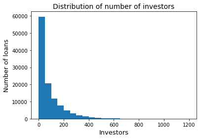

```python
custom_hist(data=master_loan_df, column='Investors', left_most=0, bin_width=50)
set_plot_labels(plot_title="Distribution of number of investors", x_label="Investors", y_label=common_loan_axis_title);
```

The data suggests that for most of the loans, the number of investors is from 1 to 100. Only in a few cases, do we have more than 500 investors funding a loan. In extremely few cases, we have more than 900 investors. Although these are outliers in the data, I will leave them for now because I want to find out what type of loans are associated with such high numbers of investors.

Next, will look at some of the features that will help in my investigation. This will involve the exploration of the characteristics of the loans (for example, loan amount, loan term, interest rate etc) and an exploration of the characteristics of the borrowers for example employment status, income, borrower type etc.

### Understanding Prosper's Loans

#### What is the distribution of the loan amounts?

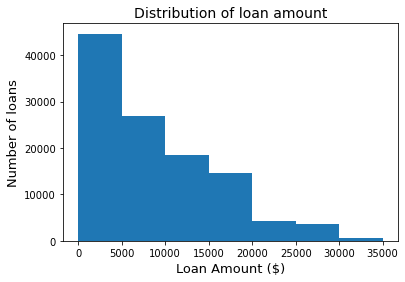

```python
custom_hist(data=master_loan_df, column='LoanOriginalAmount', left_most=0, bin_width=5000)
set_plot_labels(plot_title='Distribution of loan amount', y_label=common_loan_axis_title, x_label='Loan Amount ($)');
```

Most of the loans gotten by Prosper's borrowers do not exceed 10000 dollars. There are, however, a few loans that are between 30000 and 35000 dollars.

#### What loan terms are available?

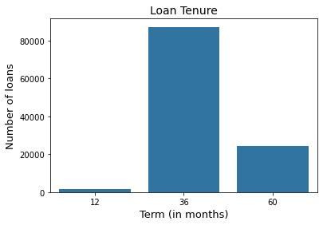

```python
order = category_order(master_loan_df, 'Term', order='custom', order_list=[12,36,60])
sns.countplot(data=master_loan_df, x='Term', order=order, color=default_color)
set_plot_labels(plot_title='Loan Tenure', y_label=common_loan_axis_title, x_label='Term (in months)');
```

The loan terms available are 12, 36 and 60 months. Most of the loans in the data have a loan term of 36 months.

#### What are the distributions of the estimated return and borrower's interest rate on Prosper's loans?

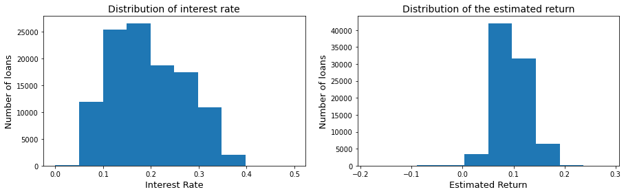

```python
fig = plt.figure(figsize=(15,4))

# Interest rate is in the BorrowerRate column
plt.subplot(1,2,1)
plt.hist(data=master_loan_df, x='BorrowerRate')
set_plot_labels(plot_title="Distribution of interest rate", x_label="Interest Rate", y_label=common_loan_axis_title);

plt.subplot(1,2,2)
plt.hist(data=master_loan_df, x='EstimatedReturn')
set_plot_labels(plot_title="Distribution of the estimated return", x_label="Estimated Return", y_label=common_loan_axis_title);
```

The interest rate on most of the loans is between 10% and 20%. There are also a few loans with interest rate of almost 50%. Furthermore, the expected return on most of the loans is between 5% and 15%.

#### What is the employment status associated with most of the loans?

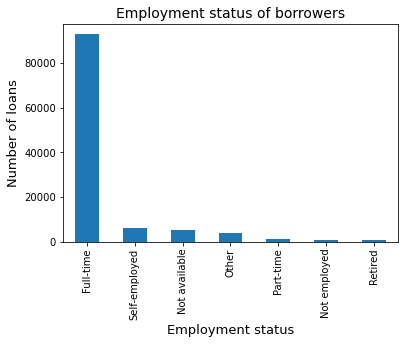

```python
master_loan_df.EmploymentStatus.value_counts().plot(kind='bar')
set_plot_labels(plot_title="Employment status of borrowers", x_label="Employment status", y_label=common_loan_axis_title);
```

Most of Prosper's loans are associated with borrowers who are in full time employment. Those who are retired and not employed make up only a small number of borrowers.

#### What income is associated with most of the loans?

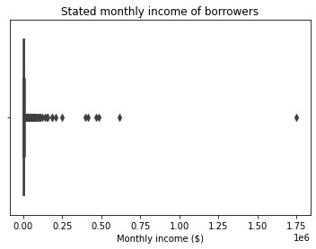

```python
sns.boxplot(data=master_loan_df, x='StatedMonthlyIncome')
plt.title('Stated monthly income of borrowers')
plt.xlabel('Monthly income ($)');
```

```python
# Comparison of the loans with stated monthly income greater and less than or equal to 50000
print(f"Loans with stated monthly income greater than 50000: {master_loan_df[master_loan_df['StatedMonthlyIncome'] > 50000].shape[0]}")
print(f"Loans with stated monthly income less than 50000: {master_loan_df[master_loan_df['StatedMonthlyIncome'] <= 50000].shape[0]}")
```

```
Loans with stated monthly income greater than 50000: 81
Loans with stated monthly income less than 50000: 112985
```

The distribution of stated monthly income is influenced by a few extremely large values. These values are in excess of 50000 dollars, with one data point showing a value greater than one million dollars. Although these extreme values distort the general distribution of the stated monthly income of Prosper's borrowers, I will not deal with them at this point. These will be handled later in the exploration after the feature is considered along with other variables.

#### Are most loans associated with borrowers who own homes?

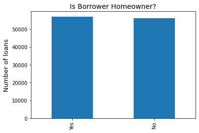

```python
master_loan_df.IsBorrowerHomeowner.value_counts().plot(kind='bar')
set_plot_labels(plot_title='Is Borrower Homeowner?', y_label=common_loan_axis_title);
```

There isn't much difference in the number of loans that are associated with borrowers who own homes and those who don't.

#### Are most loans associated with new or old borrowers?

Here, new borrowers are the ones in the data without prior loans while old borrowers are returning customers, those who have prior loans. The values are stored in the column `BorrowerType`.

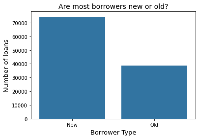

```python
cat_order = category_order(data=master_loan_df, column='BorrowerType')
sns.countplot(data=master_loan_df, x='BorrowerType', color=default_color, order=cat_order)
set_plot_labels(plot_title='Are most borrowers new or old?', x_label='Borrower Type', y_label=common_loan_axis_title);
```

#### What risk level is associated with most of the loans?

For this, I have decided to segment the risk score into bins that classify a score as either high risk, moderate risk or low risk. Risk scores from 1 to 4.5 (4.5 inclusive) are classified as "High", 4.5 to 9 (9 inclusive) as "Moderate" and above 9 as "Low".

```python
def create_bins(data, intervals, labels, include_lower_limit=False):
    return pd.cut(data, intervals, labels = labels, include_lowest=include_lower_limit)
```

```python
# use the create_bins function to create a column "RiskLevel"
# that classifies the risk scores
master_loan_df.loc[:,'RiskLevel'] = create_bins(data=master_loan_df.RiskScore, intervals=[1,4.5,9,10], labels=['High', 'Moderate', 'Low'], include_lower_limit=True)
```

```python
# Change the data type of the "RiskLevel" column
cat_dtype = pd.api.types.CategoricalDtype(categories=['Low','Moderate','High'], ordered=True)
master_loan_df['RiskLevel'] = master_loan_df['RiskLevel'].astype(cat_dtype)

master_loan_df.RiskLevel.dtype
```

```
CategoricalDtype(categories=['Low', 'Moderate', 'High'], ordered=True)
```

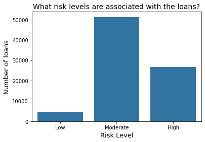

```python
sns.countplot(data=master_loan_df, x='RiskLevel', color=default_color)
set_plot_labels(plot_title='What risk levels are associated with the loans?', x_label='Risk Level', y_label=common_loan_axis_title);
```

Based on Prosper's custom risk score, the majority of loans are associated with borrowers whose risk level can be said to be moderate followed by loans for borrowers in the high risk category. A very small number of loans are associated with low risk borrowers.

### Discuss the distribution(s) of your variable(s) of interest. Were there any unusual points? Did you need to perform any transformations?

The number of investors that fund most of the loans is between 0 and 100. In extremely few cases, we have more than 900 investors funding a loan. Although these are outliers in the data, I have left them for now because it will be interesting to find out what type of loans are associated with such high numbers of investors.

### Of the features you investigated, were there any unusual distributions? Did you perform any operations on the data to tidy, adjust, or change the form of the data? If so, why did you do this?

The `StatedMonthlyIncome` variable has a few extremely large values, in excess of 50000 dollars, with one data point showing a value greater than one million dollars. Although these extreme values distort the general distribution of the stated monthly income, I have not dealt with them at this point as I want to see how the variable interacts with other features in the next stage of the exploration.

## Bivariate Exploration

In this section, I will investigate relationships between my main variable of interest (the number of investors funding a loan) and the supporting features which include employment status, income, home ownership, borrower type, risk level, loan amount and loan term. I will also explore some relationships among the supporting features whenever it is necessary to answer certain questions.

#### Is there a relationship between the number of investors and loan amount?

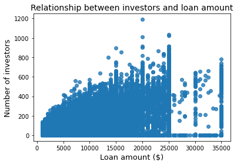

```python
sns.regplot(data=master_loan_df, y='Investors', x='LoanOriginalAmount', fit_reg=False)
set_plot_labels(plot_title='Relationship between investors and loan amount', x_label='Loan amount ($)', y_label=common_investor_axis_title);
```

There doesn't seem to be any relationship between the loan amount and the number of investors funding the loan. The unusual number of investors observed earlier (that is, above 900) are associated with loans in the range of USD20000 to USD25000. What if a log transform is performed on the x-axis.

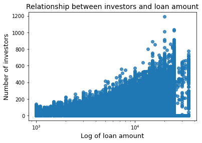

```python
sns.regplot(data=master_loan_df, y='Investors', x='LoanOriginalAmount', fit_reg=False)
plt.xscale('log')
set_plot_labels(plot_title='Relationship between investors and loan amount', x_label='Log of loan amount', y_label=common_investor_axis_title);
```

Even after plotting loan amount on a log scale, there doesn't seem to be any relationship between loan amount and the number of investors.

#### Does loan term influence investors?

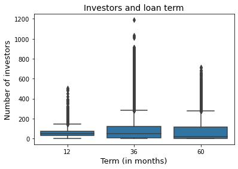

```python
sns.boxplot(data=master_loan_df, y='Investors', x='Term', color=default_color)
set_plot_labels(plot_title='Investors and loan term', x_label='Term (in months)', y_label=common_investor_axis_title);
```

Regardless of term, most of the loans have less than 200 investors. Loans that run for 36 months seem to have a high number of investors, going as high as 1200 although this could be because of the high number of loans with a term of 36 months in the data.

Based on the median, however, 12 and 36 months loans have a similar number of investors while 60 months loans have the lowest median number of investors. To see this clearly, I have plotted the median number of investors in each term on a bar chart (shown below). I have opted to use the median instead of the mean due to the presence of outliers that could otherwise influence the mean.

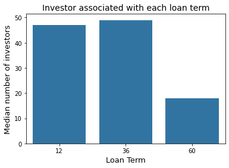

```python
median_investors = master_loan_df.groupby('Term').median()['Investors']
sns.barplot(x=median_investors.index, y=median_investors.values, color=default_color)
set_plot_labels("Investor associated with each loan term", "Loan Term", "Median number of investors");
```

The bar chart clearly shows that although loans with a term of 36 months have a higher median number of investors, loans that run for 12 months equally have a considerable number of investors. Infact, both 12 and 36 months loans have a median number of investors close to 50. Only 60 months loans have a median number of investors that is less than 20.

#### Is there a relationship between the number of investors and both interest rate (borrower rate) and estimated return?

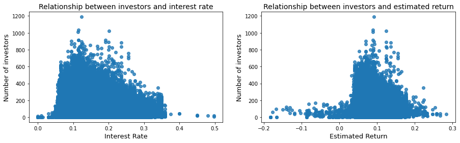

```python
fig2 = plt.figure(figsize=(15,4))

plt.subplot(1,2,1)
sns.regplot(data=master_loan_df, y='Investors', x='BorrowerRate', fit_reg=False)
set_plot_labels(plot_title="Relationship between investors and interest rate", x_label="Interest Rate", y_label=common_investor_axis_title);

plt.subplot(1,2,2)
sns.regplot(data=master_loan_df, y='Investors', x='EstimatedReturn', fit_reg=False)
set_plot_labels(plot_title="Relationship between investors and estimated return", x_label="Estimated Return", y_label=common_investor_axis_title);
```

The relationships between the number of investors and interest rate and the number of investors and estimated return are similar. This is expected because estimated return is based on interest rate. A positive relationship between the two variables can be seen in the scatter plot below.

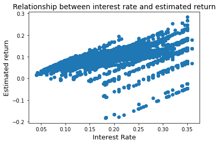

```python
plt.scatter(data=master_loan_df, x='BorrowerRate', y='EstimatedReturn')
set_plot_labels(plot_title="Relationship between interest rate and estimated return", x_label="Interest Rate", y_label='Estimated return');
```

All in all, there doesn't seem to be a relationship between the borrower's interest rate and the number of investors. Its actually unusual that loans with high interest rates, for example, close to 50% are associated with very few investors while loans with interest rates between 10% and 30% seem to be associated with a very high number of investors. Similarly, loans with a high estimated return (close to 30%) seem to be associated with very few investors while loans with an estimated return of between 5% and 20% seem to attract more investors. Could it be that low interest rates signify low risk and therefore more attractive to investors?

To see this clearly, I want to check if there is a relationship between interest rate and risk level.

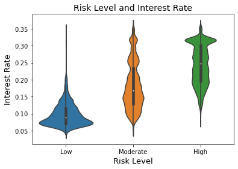

```python
sns.violinplot(data=master_loan_df, x='RiskLevel', y='BorrowerRate')
set_plot_labels('Risk Level and Interest Rate', 'Risk Level', 'Interest Rate');
```

The data seems to suggest that indeed most of the loans that are associated with borrowers that are in the low risk category have lower interest rates than loans for moderate and high risk borrowers. Even in terms of the median, loans associated with borrowers in the high risk category have the highest median interest rate while loans for low risk borrowers have the lowest. This could explain why loans with relatively low interest rates and thus estimated return seem to be associated with a high number of investors. Perhaps most investors are risk averse?

#### Is there a relationship between borrowers' monthly income and the number of investors?

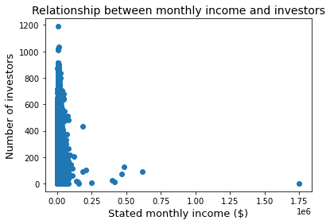

```python
plt.scatter(data=master_loan_df, y='Investors', x='StatedMonthlyIncome')
set_plot_labels('Relationship between monthly income and investors', 'Stated monthly income ($)', y_label=common_investor_axis_title);
```

As observed earlier in the exploration, stated monthly income has a few extremely large values, which are visible even in the scatter plot above. Before dealing with these outliers, I want to check whether these levels of income are reasonable. This will be done by looking at whether the income is verifiable, what the employment status of the borrowers is and what the associated loan amounts are.

Firstly, will check if the monthly income outliers are verifiable.

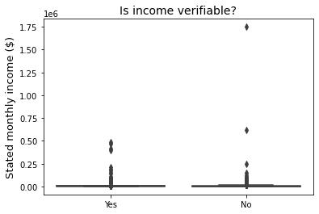

```python
sns.boxplot(data=master_loan_df, x='IncomeVerifiable', y='StatedMonthlyIncome')
set_plot_labels('Is income verifiable?', y_label='Stated monthly income ($)');
```

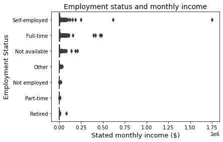

```python
sns.boxplot(data=master_loan_df, y='EmploymentStatus', x='StatedMonthlyIncome')
set_plot_labels('Employment status and monthly income', x_label='Stated monthly income ($)', y_label='Employment Status');
```

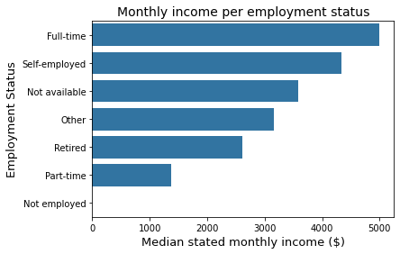

```python
data = master_loan_df.groupby('EmploymentStatus').median()['StatedMonthlyIncome'].sort_values(ascending=False)
sns.barplot(x=data.values, y=data.index, color=default_color)
set_plot_labels('Monthly income per employment status', x_label='Median stated monthly income ($)', y_label='Employment Status');
```

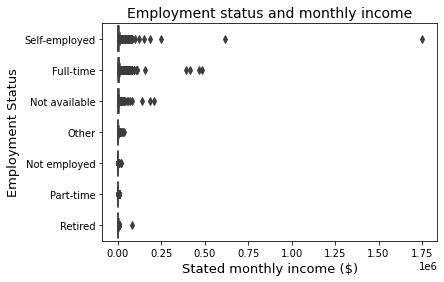

```python
sns.boxplot(data=master_loan_df, y='EmploymentStatus', x='StatedMonthlyIncome')
plt.xlabel('Stated monthly income ($)');
set_plot_labels('Employment status and monthly income', x_label='Stated monthly income ($)', y_label='Employment Status');
```

My last check is to see what loan amounts are associated with the monthly income outliers.

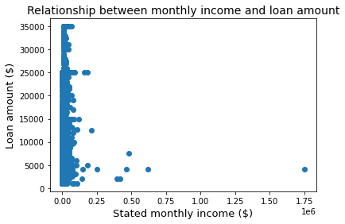

```python
plt.scatter(data=master_loan_df, y='LoanOriginalAmount', x='StatedMonthlyIncome')
set_plot_labels('Relationship between monthly income and loan amount', 'Stated monthly income ($)', 'Loan amount ($)');
```

The scatter plot shows that the extremely large monthly income values are associated with smaller loan amounts (less than ten thousand dollars), which is unusual. For example, the borrower with a stated monthly income of over one million dollars has a loan amount of about five thousand dollars, which is quite unusual.

The first and third checks suggest to me that the extremely large stated monthly income values may have been a result of errors in the data. In analyzing monthly income, therefore, I will not consider these outliers (in this case, the values that are greater than 50000 dollars). Furthermore, I will only consider income values that are verifiable.

Now lets see how the relationship between monthly income and investors looks.

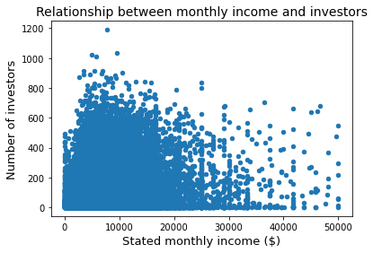

```python
# filter stated monthly income values that are less than or equal to 50000 and are verifiable

master_loan_df.query('StatedMonthlyIncome <= 50000 & IncomeVerifiable == "Yes"').plot(kind='scatter', x='StatedMonthlyIncome', y='Investors')
set_plot_labels(plot_title='Relationship between monthly income and investors', x_label='Stated monthly income ($)', y_label=common_investor_axis_title);
```

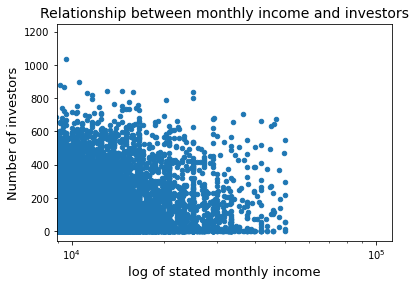

```python
# Plot monthly income on a log scale
master_loan_df.query('StatedMonthlyIncome <= 50000 & IncomeVerifiable == "Yes"').plot(kind='scatter', x='StatedMonthlyIncome', y='Investors')
plt.xscale('log')
set_plot_labels(plot_title='Relationship between monthly income and investors', x_label='log of stated monthly income', y_label=common_investor_axis_title);
```

Even without outliers, there is no relationship between stated monthly income and the number of investors. Plotting the monthly income on a log scale does not show any relationship between the two either.

#### Which employment status is associated with a high number of investors?

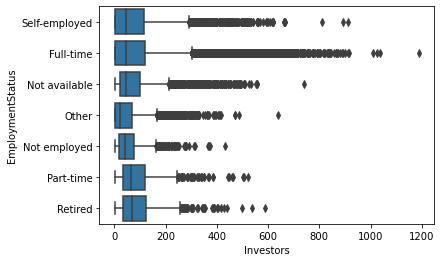

```python
sns.boxplot(data=master_loan_df, y='EmploymentStatus', x='Investors', color=default_color);
```

Loans for full-time and self-employed borrowers seem to be associated with a very high number of investors looking at the distribution of the data points. Surprisingly, however, the median number of investors is higher for loans associated with retired and part-time borrowers than full-time and self-employed borrowers. This can clearly be seen in the bar chart below. What might explain this? In the next section, will explore this question.

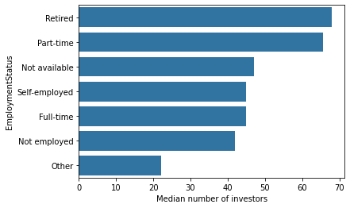

```python
# Plot the median number of investors for each employment status
data = master_loan_df.groupby('EmploymentStatus').median()['Investors'].sort_values(ascending=False)
sns.barplot(y=data.index, x=data.values, color=default_color)
plt.xlabel('Median number of investors');
```

#### Does home ownership influence the number of investors funding a loan?

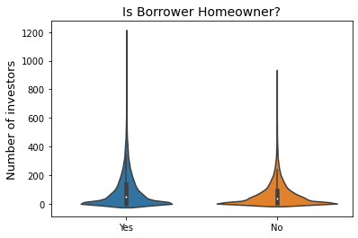

```python
sns.violinplot(data=master_loan_df, y='Investors', x='IsBorrowerHomeowner')
set_plot_labels(plot_title='Is Borrower Homeowner?', y_label=common_investor_axis_title);
```

The data seems to suggest that loans for borrowers who own homes are associated with a high number of investors. If we ignore the outliers (the extremely high number of investors) in the data, there isn't much difference in the distributions of loans for borrowers with and without own homes.

#### Are investors more likely to fund loans for old borrowers than new borrowers?

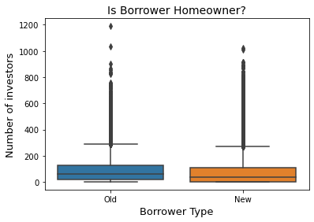

```python
sns.boxplot(data=master_loan_df, x='BorrowerType', y='Investors')
set_plot_labels(plot_title='Is Borrower Homeowner?', y_label=common_investor_axis_title, x_label='Borrower Type');
```

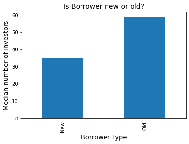

```python
master_loan_df.groupby('BorrowerType').median()['Investors'].plot(kind='bar');
set_plot_labels(plot_title='Is Borrower new or old?', y_label='Median number of investors', x_label='Borrower Type');
```

### Talk about some of the relationships you observed in this part of the investigation. How did the feature(s) of interest vary with other features in the dataset?

However, it was interesting that loans with high interest rates and thus estimated return were associated with very few investors while loans with relatively low interest rates and estimated return seemed to have a very high number of investors. In the next section, will explore if there are other variables in the data that support this.

### Did you observe any interesting relationships between the other features (not the main feature(s) of interest)?

Since loans with relatively low interest rate and estimated return were associated with a high number of investors, I wanted to check whether the low interest rates would signify low risk thus making the loans more attractive to investors. To do this, I explored the relationship between risk level and interest rate. The results showed that most of the loans that were associated with borrowers in the low or moderate risk category had lower interest rates than loans for borrowers in the high risk category. These preliminary results seem to have supported the proposition that relatively low interest rates could signify low risk thus making such loans more attractive to investors.

## Multivariate Exploration

In the previous section, the data seemed to support the proposition that relatively low interest rates could signify relatively low risk, thus making loans with low interest rates more attractive to a good number of investors. In this section, therefore, I want to explore what other loan characteristics are associated with low risk. How do they affect the number of investors funding a loan? Similarly, the data showed that loans with a high estimated return were associated with very few investors while loans with a relatively low estimated return seemed to have a very high number of investors. So I want to explore whether this occurrence is supported by other variables.

The results of the previous section also showed that loans associated with part-time or retired borrowers had a higher median number of investors than those for full-time or self-employed borrowers. This was despite the fact that loans for full-time and self-employed borrowers had the highest number of investors in absolute terms. Therefore, I want to explore whether this was an isolated case (purely due to the presence of outliers) or is supported by other variables in the data.

### Context

```python
# Create a copy of the master_loan_df
final_loan_df = master_loan_df.copy()
```

```python
# Drop the rows that have unverified income and
# stated monthly income greater than $ 50000
rows_to_drop = final_loan_df.query('StatedMonthlyIncome > 50000 & IncomeVerifiable == "No"').index
final_loan_df.drop(rows_to_drop, inplace=True)
```

### Investors and estimated return in the context of other variables

#### What loan amounts have an estimated return that is associated with a high number of investors?

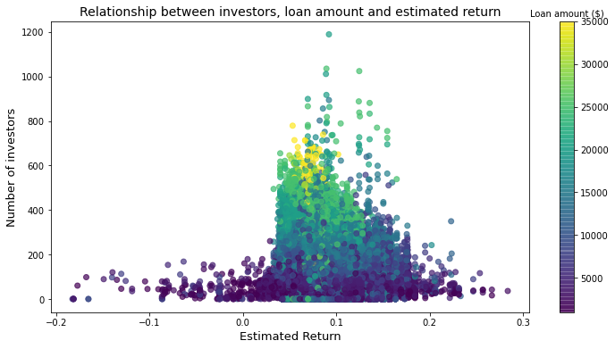

```python
plt.rcParams["figure.figsize"]=(12,6)
plt.scatter(data=final_loan_df, y='Investors', x='EstimatedReturn', c='LoanOriginalAmount', alpha=0.7)
plt.colorbar().ax.set_title('Loan amount ($)', fontsize=10)
set_plot_labels(plot_title="Relationship between investors, loan amount and estimated return", x_label="Estimated Return", y_label=common_investor_axis_title);
```

As earlier observed, loans with a high estimated return (close to 30%) seem to be associated with very few investors while loans with an estimated return of between 5% and 20% seem to attract more investors. Loans with an estimated return of about 10% have the highest number of investors. These loans have loan amounts between 20000 and 30000 dollars. One thing worth noting about most of the loans with an estimated return close to 30% but small number of investors is that the loan amounts are also relatively smaller (less than 10000 dollars). Looks like loan amount also does have an influence on investors.

#### What loan terms have an estimated return that is associated with a high number of investors?

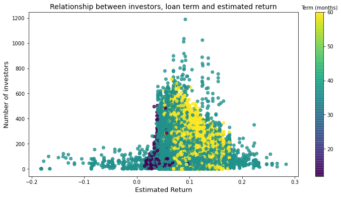

```python
plt.rcParams["figure.figsize"]=(12,6)
plt.scatter(data=final_loan_df, y='Investors', x='EstimatedReturn', c='Term', alpha=0.8)
plt.colorbar().ax.set_title('Term (months)', fontsize=10)
set_plot_labels(plot_title="Relationship between investors, loan term and estimated return", x_label="Estimated Return", y_label=common_investor_axis_title);
```